# Practical Machine Learning - Course Project

Robert

February 28, 2016

## Synopsis

##### Quoted directly from the project outline

Using devices such as Jawbone Up, Nike FuelBand, and Fitbit it is now possible to collect a large amount of data about personal activity relatively inexpensively. These type of devices are part of the quantified self movement – a group of enthusiasts who take measurements about themselves regularly to improve their health, to find patterns in their behavior, or because they are tech geeks. One thing that people regularly do is quantify how much of a particular activity they do, but they rarely quantify how well they do it.

In this project, your goal will be to use data from accelerometers on the belt, forearm, arm, and dumbell of 6 participants. They were asked to perform barbell lifts correctly and incorrectly in 5 different ways. More information is available from the website here: http://groupware.les.inf.puc-rio.br/har (see the section on the Weight Lifting Exercise Dataset).

### Data

We have downloaded the data for the training and test data sets to our working directory.

```r
trainingDataCsv <- "trainingData.csv"
testingDataCsv <- "testing.csv"
trainingDataSource <-"https://d396qusza40orc.cloudfront.net/predmachlearn/pml-training.csv"
testingDataSource <- "https://d396qusza40orc.cloudfront.net/predmachlearn/pml-testing.csv"
if (!file.exists(trainingDataCsv)){ download.file(trainingDataSource, destfile=trainingDataCsv) }
if (!file.exists(testingDataCsv)){ download.file(testingDataSource, destfile=testingDataCsv) }
```

The training data set for this project is available here:  
https://d396qusza40orc.cloudfront.net/predmachlearn/pml-training.csv

The test data set is available here:  
https://d396qusza40orc.cloudfront.net/predmachlearn/pml-testing.csv

Using this data we will use the training dta set to build a model which will be used to predict the “classe” label of the test data set. This is a predictione exercise and the type of prdediction is “Classification”.

### Required libraries

The following libraries are requiuired and assumed to be installed. Additionally the version of caret is shown.

```r
library("caret")
library("data.table")
library("arm")
library("doMC")
registerDoMC(cores = 5)
packageVersion("caret")
```

```
## [1] '6.0.64'
```

### Download data and initial exploration

First we use the “fread” function from the “data.table” package to read the data, defining blank strings and the value “NA” as the ‘NA’ strings.

```r
trainingDataSet <- fread(trainingDataCsv, na.strings=c("", "NA"))
testingDataSet <- fread(testingDataCsv, na.strings=c("", "NA"))
# Convert classe to a Factor variable
trainingDataSet$classe <- as.factor(trainingDataSet$classe)
```

The data is clean: variables are in a single column, with each observation in a single row. The data structure is both large and sparse. Analysing the data structure in detail would make the project excessively large in terms of the number of pages, so for brevity the specifics of this analysis are not included.

The Response variable “classe” has a distribution as shown below. Class A is the most frequent level and the remaining 4 levels appear to be within a close range. There is a dominant level but in my opinion the dominance is not heavy and that overall the levels are reasonably balanced.

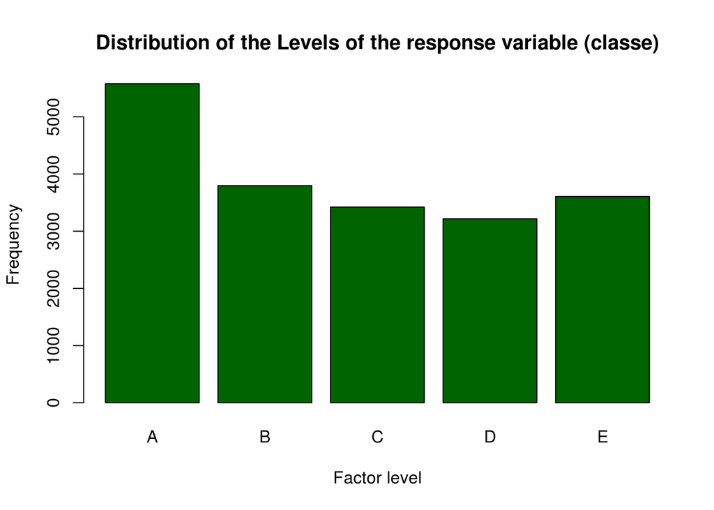

```r
plot(trainingDataSet$classe, col="darkgreen", main='Distribution of the Levels of the response variable (classe)', xlab="Factor level", ylab="Frequency")
```

```r
table(trainingDataSet$classe)
```

```
##
##    A    B    C    D    E
## 5580 3797 3422 3216 3607
```

```r
naSumCutOff <- 0.9
```

We will get rid of columns that have a large proportion (over 90%) of “NA” values and where we cannot infer any reasonable value. The first seven columns (user_name, raw_timestamp_part_1, raw_timestamp_part_2, cvtd_timestamp, new_window and num_window) are date/time or indentification values and in my opinion are not relevant to any predictive model and therefore are removed.

```r
nonSparseColumns <- colSums(is.na(trainingDataSet)) <= nrow(trainingDataSet) * naSumCutOff
names <- names(trainingDataSet)
names[1:7]
```

```
## [1] "V1"                   "user_name"            "raw_timestamp_part_1"
## [4] "raw_timestamp_part_2" "cvtd_timestamp"       "new_window"
## [7] "num_window"
```

```r
irrelevantColumns <- c(1:7)
#Convert to a data frame and then select the columns
trainingDataSet <- data.frame(trainingDataSet)[ , nonSparseColumns]
#Remove the first 7 columns, because this data is irrelevant (Name, Date/Time, row index, ...)
trainingDataSet <- trainingDataSet[ , -irrelevantColumns]
testingDataSet <- data.frame(testingDataSet)[ , nonSparseColumns]
testingDataSet <- testingDataSet[ , -irrelevantColumns]
```

The number of columns removed because of sparse data is 60. Some attributes may have a low variance, which means that the attribute values will be nearly the same for all observations. Low variance data is not very useful for predictive models and should be removed. The caret package provides us with a useful utility to find any such attributes and from the data that has already been cleaned already there appear to be no low variance variables remaining.

```r
lowVariance <- nearZeroVar(trainingDataSet, saveMetrics=T)
lowVariance[lowVariance$nzv == TRUE,]
```

```
## [1] freqRatio     percentUnique zeroVar       nzv
## <0 rows> (or 0-length row.names)
```

```r
trainingDataSet <- trainingDataSet[, !(lowVariance$nzv)]
testingDataSet <- testingDataSet[, !(lowVariance$nzv)]
corrCutoff <- 0.8
```

We will also check for any predictors that are highly correlated so we will remove the highly correlated predictors, those with absolute correlations above 0.8 . Variables that are highly correlated tend to change together so changing the value in one variable would usually mean a change in highly correlated variable.

```r
# classe is the last attribute, remove it for the correlation function
colCount <- dim(trainingDataSet)[2]
trainingCorr <- cor(trainingDataSet[, -colCount])
highlyCorPred <- findCorrelation(trainingCorr, cutoff=corrCutoff)
trainingDataSet <- trainingDataSet[,-highlyCorPred]
trainingDataSet <- trainingDataSet[,-highlyCorPred]

trainValidationSplit <- 0.75
numberOfFolds <- 10
numberOfRepeats <- 5
```

### Partition the Data

Now we will partition our data into a training and validation set. We will take 75% of our data for training the model and the remaining 25% for model validation. We will split over the response variable to get an equal proportion of “classe” values in each set.

```r
set.seed(8020)
trainIndex <- createDataPartition(trainingDataSet$classe, p=trainValidationSplit, list=FALSE, times=1)
trainingSet <- trainingDataSet[trainIndex,]
validationSet <- trainingDataSet[-trainIndex,]
```

### Finding our Model

```r
fitControl <- trainControl(method="cv", number=numberOfFolds, repeats=numberOfRepeats)
```

To train our model and to compare two different models, we will try with a boosted model and then we will use a Random Forest model. They are both models widely used for classification problems such as the prediction problem that we are trying to solve.

1. Generalised Boosted Model (GBM). We use the caret package to train the model, the method argument will use the “gbm” method to build our model.

```r
gbm.fit <- train(classe ~ . , data=trainingSet,
                 method="gbm", trControl=fitControl, verbose=FALSE)
gbm.fit
```

```
## Stochastic Gradient Boosting
##
## 14718 samples
##    27 predictors
##     5 classes: 'A', 'B', 'C', 'D', 'E'
##
## No pre-processing
## Resampling: Cross-Validated (10 fold)
## Summary of sample sizes: 13247, 13247, 13246, 13245, 13246, 13246, ...
## Resampling results across tuning parameters:
##
##   interaction.depth  n.trees  Accuracy   Kappa      Accuracy SD
##   1                   50      0.6996215  0.6179107  0.010147521
##   1                  100      0.7543135  0.6878443  0.010524089
##   1                  150      0.7840713  0.7257790  0.010020096
##   2                   50      0.7924290  0.7362326  0.008323368
##   2                  100      0.8422989  0.7999777  0.009379869
##   2                  150      0.8717187  0.8374853  0.008806184
##   3                   50      0.8304780  0.7848539  0.007241716
##   3                  100      0.8804839  0.8485695  0.007368543
##   3                  150      0.9105157  0.8866948  0.007513920
##   Kappa SD
##   0.012960359
##   0.013246774
##   0.012627979
##   0.010529705
##   0.011828333
##   0.011147729
##   0.009232755
##   0.009367236
##   0.009524249
##
## Tuning parameter 'shrinkage' was held constant at a value of 0.1
##
## Tuning parameter 'n.minobsinnode' was held constant at a value of 10
## Accuracy was used to select the optimal model using  the largest value.
## The final values used for the model were n.trees = 150,
##  interaction.depth = 3, shrinkage = 0.1 and n.minobsinnode = 10.
```

2. Random Forest model. Again using the caret package, we give the method argument as “rf”, to se a Random Forest to build our model.

```r
rf.fit1 <- train(classe ~ . , data=trainingSet,
                 method="rf", trControl=fitControl, verbose=FALSE)
rf.fit1
```

```
## Random Forest
##
## 14718 samples
##    27 predictors
##     5 classes: 'A', 'B', 'C', 'D', 'E'
##
## No pre-processing
## Resampling: Cross-Validated (10 fold)
## Summary of sample sizes: 13245, 13246, 13245, 13247, 13247, 13245, ...
## Resampling results across tuning parameters:
##
##   mtry  Accuracy   Kappa      Accuracy SD  Kappa SD
##    2    0.9837620  0.9794507  0.003406909  0.004314526
##   14    0.9831512  0.9786805  0.004941616  0.006261734
##   27    0.9722809  0.9649271  0.004733525  0.006001280
##
## Accuracy was used to select the optimal model using  the largest value.
## The final value used for the model was mtry = 2.
```

Random Forest gives the highest prediction accuracy. Let us see how both models do on the validation data set, which is the data that we took for validating the model created using the training data.

```r
gbmPredict <- predict(gbm.fit, validationSet)
rfPredict1 <- predict(rf.fit1, validationSet)
```

### Prediction performance using the Validation Data Set

```r
gbmPredict.cm <- confusionMatrix(gbmPredict, validationSet$classe)
gbmPredictAccuracy <- round(gbmPredict.cm$overall["Accuracy"],4)
rfPredict1.cm <- confusionMatrix(rfPredict1, validationSet$classe)
rfPredictAccuracy <- round(rfPredict1.cm$overall["Accuracy"], 4)
```

The GBM model gives an accuracy of 90.46% with the validation data, which is a high accuracy rate. Random guessing would have a rate of 0.2, so our model performs considerably better.

```r
gbmPredict.cm
```

```
## Confusion Matrix and Statistics
##
##           Reference
## Prediction    A    B    C    D    E
##          A 1349   67   11   15   11
##          B   17  788   52    8   19
##          C   11   64  778   64   31
##          D   17   22   12  704   23
##          E    1    8    2   13  817
##
## Overall Statistics
##
##                Accuracy : 0.9046
##                  95% CI : (0.896, 0.9127)
##     No Information Rate : 0.2845
##     P-Value [Acc > NIR] : < 2.2e-16
##
##                   Kappa : 0.8791
##  Mcnemar's Test P-Value : < 2.2e-16
##
## Statistics by Class:
##
##                      Class: A Class: B Class: C Class: D Class: E
## Sensitivity            0.9670   0.8303   0.9099   0.8756   0.9068
## Specificity            0.9704   0.9757   0.9580   0.9820   0.9940
## Pos Pred Value         0.9284   0.8914   0.8207   0.9049   0.9715
## Neg Pred Value         0.9867   0.9600   0.9805   0.9758   0.9793
## Prevalence             0.2845   0.1935   0.1743   0.1639   0.1837
## Detection Rate         0.2751   0.1607   0.1586   0.1436   0.1666
## Detection Prevalence   0.2963   0.1803   0.1933   0.1586   0.1715
## Balanced Accuracy      0.9687   0.9030   0.9340   0.9288   0.9504
```

However it was not the best model. The Random Forest model achieved an accuracy of 98.41% with the validation data. The confusion matrix below shows that here were very few false classifications, and this is the better model.

```r
rfPredict1.cm
```

```
## Confusion Matrix and Statistics
##
##           Reference
## Prediction    A    B    C    D    E
##          A 1394   19    1    0    0
##          B    1  923   17    0    0
##          C    0    6  836   29    2
##          D    0    1    1  775    1
##          E    0    0    0    0  898
##
## Overall Statistics
##
##                Accuracy : 0.9841
##                  95% CI : (0.9802, 0.9874)
##     No Information Rate : 0.2845
##     P-Value [Acc > NIR] : < 2.2e-16
##
##                   Kappa : 0.9799
##  Mcnemar's Test P-Value : NA
##
## Statistics by Class:
##
##                      Class: A Class: B Class: C Class: D Class: E
## Sensitivity            0.9993   0.9726   0.9778   0.9639   0.9967
## Specificity            0.9943   0.9954   0.9909   0.9993   1.0000
## Pos Pred Value         0.9859   0.9809   0.9576   0.9961   1.0000
## Neg Pred Value         0.9997   0.9934   0.9953   0.9930   0.9993
## Prevalence             0.2845   0.1935   0.1743   0.1639   0.1837
## Detection Rate         0.2843   0.1882   0.1705   0.1580   0.1831
## Detection Prevalence   0.2883   0.1919   0.1780   0.1586   0.1831
## Balanced Accuracy      0.9968   0.9840   0.9843   0.9816   0.9983
```

With a 95% confidence interval of classifying between 98.02 and 98.74 of the classes correctly, this is a very high rate.

### Can we simplify the model ?

We do have a model that has potentially many predictors and we might be able to simplify this model and keep a similar accuracy. Below we show the variable importance and by removing less important parameters maybe we could find a more parsimonious model.

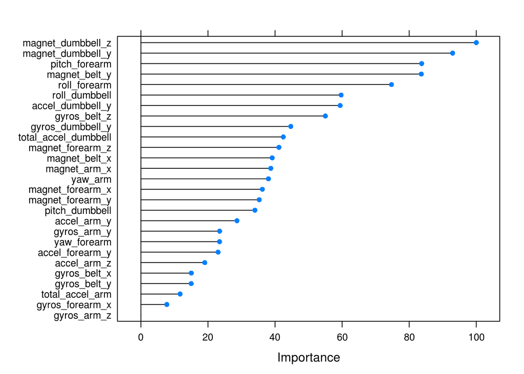

```r
importanceThreshold <- 20
predictorImportance <- varImp(rf.fit1)
plot(predictorImportance)
```

```r
varImportance <- predictorImportance[[1]]
importantVariables <- rownames(varImportance)[order(rowSums(varImportance), decreasing=TRUE)][rowSums(varImportance) > importanceThreshold]
simpleCount <- length(importantVariables)
importantVariables <- c(importantVariables, "classe")
```

Now that we have the most important variables, we will generate a new model model. There are several predictors with a low important so to make the model more understandable we can remove the low importance variables and check the accuracy. I have selected the 21 most important parameters, based on having a scaled importance of more than 20 and we will run the Random Forest model generation using these variables.

```r
trainingSet2 <- trainingSet[, importantVariables]
rf.fit2 <- train(classe ~ ., data=trainingSet2,
                 method="rf", trControl=fitControl, verbose=FALSE)
rf.fit2
```

```
## Random Forest
##
## 14718 samples
##    21 predictors
##     5 classes: 'A', 'B', 'C', 'D', 'E'
##
## No pre-processing
## Resampling: Cross-Validated (10 fold)
## Summary of sample sizes: 13245, 13246, 13247, 13246, 13245, 13247, ...
## Resampling results across tuning parameters:
##
##   mtry  Accuracy   Kappa      Accuracy SD  Kappa SD
##    2    0.9779180  0.9720608  0.002906017  0.003676081
##   11    0.9716676  0.9641512  0.002808520  0.003551736
##   21    0.9538669  0.9416303  0.004670260  0.005912628
##
## Accuracy was used to select the optimal model using  the largest value.
## The final value used for the model was mtry = 2.
```

Let us see how well it predicts using the validation set.

```r
predict.rf.2 <- predict(rf.fit2, validationSet)
predict.rf.2.cm <- confusionMatrix(predict.rf.2, validationSet$classe)
predict.rf.2.cm
```

```
## Confusion Matrix and Statistics
##
##           Reference
## Prediction    A    B    C    D    E
##          A 1391   17    3    2    2
##          B    4  920   19    1    0
##          C    0    9  828   34    4
##          D    0    3    5  766    2
##          E    0    0    0    1  893
##
## Overall Statistics
##
##                Accuracy : 0.9784
##                  95% CI : (0.9739, 0.9823)
##     No Information Rate : 0.2845
##     P-Value [Acc > NIR] : < 2.2e-16
##
##                   Kappa : 0.9726
##  Mcnemar's Test P-Value : NA
##
## Statistics by Class:
##
##                      Class: A Class: B Class: C Class: D Class: E
## Sensitivity            0.9971   0.9694   0.9684   0.9527   0.9911
## Specificity            0.9932   0.9939   0.9884   0.9976   0.9998
## Pos Pred Value         0.9830   0.9746   0.9463   0.9871   0.9989
## Neg Pred Value         0.9989   0.9927   0.9933   0.9908   0.9980
## Prevalence             0.2845   0.1935   0.1743   0.1639   0.1837
## Detection Rate         0.2836   0.1876   0.1688   0.1562   0.1821
## Detection Prevalence   0.2885   0.1925   0.1784   0.1582   0.1823
## Balanced Accuracy      0.9951   0.9817   0.9784   0.9751   0.9954
```

This gives us an accuracy value of 0.9784, and a 95% CI of an accuracy level of between 0.9739 and 0.9823. This model gives us a similar but a slighty lower accuracy rate when compared to the first Random Forest model.

### Out-of-Sample Error

The out-of-sample error rate is the error rate of the model when predicting the response variable using the validation data set and the value is defined as 1 minus the accuracy of the model. The first Random Forest model has an out-of-sample error rate as calculated below.

Expected out-of-sample error rate is: 1 - accuracy = 1 - 0.9841 = 0.0159, which converts as a percentage to 1.59%.

### Using the test data to make predictions

Using the test set with our first Random Forest prediction model, we get the predictions below for the first 20 elements of the test data.

```r
predict.rf.1.test <- predict(rf.fit1, testingDataSet)
predict.rf.1.test[1:20]
```

```
##  [1] B A B A A E D B A A B C B A E E A B B B
## Levels: A B C D E
```

### Conclusion

Based on the two generated models, we have concluded that the Random Forst model will give a better prediction accuracy and therefore a lower out-of-sample error rate.